# al_co_4_hotel

##### load dataset

```python
import pandas as pd
h1 = pd.read_csv('H1.csv')
print(h1.shape)
h1.head()
```

```
(40060, 31)
```

|  | IsCanceled | LeadTime | ArrivalDateYear | ArrivalDateMonth | ArrivalDateWeekNumber | ArrivalDateDayOfMonth | StaysInWeekendNights | StaysInWeekNights | Adults | Children | ... | DepositType | Agent | Company | DaysInWaitingList | CustomerType | ADR | RequiredCarParkingSpaces | TotalOfSpecialRequests | ReservationStatus | ReservationStatusDate |
| --- | --- | --- | --- | --- | --- | --- | --- | --- | --- | --- | --- | --- | --- | --- | --- | --- | --- | --- | --- | --- | --- |
| 0 | 0 | 342 | 2015 | July | 27 | 1 | 0 | 0 | 2 | 0 | ... | No Deposit | NULL | NULL | 0 | Transient | 0.0 | 0 | 0 | Check-Out | 2015-07-01 |
| 1 | 0 | 737 | 2015 | July | 27 | 1 | 0 | 0 | 2 | 0 | ... | No Deposit | NULL | NULL | 0 | Transient | 0.0 | 0 | 0 | Check-Out | 2015-07-01 |
| 2 | 0 | 7 | 2015 | July | 27 | 1 | 0 | 1 | 1 | 0 | ... | No Deposit | NULL | NULL | 0 | Transient | 75.0 | 0 | 0 | Check-Out | 2015-07-02 |
| 3 | 0 | 13 | 2015 | July | 27 | 1 | 0 | 1 | 1 | 0 | ... | No Deposit | 304 | NULL | 0 | Transient | 75.0 | 0 | 0 | Check-Out | 2015-07-02 |
| 4 | 0 | 14 | 2015 | July | 27 | 1 | 0 | 2 | 2 | 0 | ... | No Deposit | 240 | NULL | 0 | Transient | 98.0 | 0 | 1 | Check-Out | 2015-07-03 |

5 rows × 31 columns

### Data Science Project Life-Cycle

#### 1. Domain Understanding - 대상 분야 이해

##### 전공자, 경력자, 자격증 보유자는 특정 분야를 더 잘 알고 있습니다.

- 이 분야 사람들이 지금까지 어떤 고민을 해 왔는가?
- 해당 분야에서 주로 사용되는 특수한 알고리즘이 있나?
- 예시 : 리테일 CF, 공장 FFT, 보험 Cox-PH

#### 2. Data Understanding - 데이터 이해하기

##### 가용 데이터가 무엇인가? 어떤 형태인가?

- 특수 목적 알고리즘 사용할 경우 필요한 데이터가 있는지 파악해야 함
- CF 는 고객 - 상품 사이의 연결고리 필요, FFT 는 초당 데이터 획득 속도 높아야 함

#### 3. Data Exploration - 데이터 탐색

##### 그래프 보는 단계, 데이터로부터 인사이트 도출

- 일 안 하는 날, 출/퇴근시간에 이용객 peak가 있었음

#### 4. Data Preparation - 데이터 준비

##### 전처리, 파생변수 생성

##### 학습용 / 시험용 데이터 셋 분할

#### 5. Model Planning - 모델 기획

##### 알고리즘별 목적과 장단점이 있기 때문에 목적별로 후보군 설정

##### 장단점 방향성 3가지

- 속도 - 적용 환경에 따라(비즈니스 모델) 선택을 다르게 함
- 예측력 - 예측 모델의 예측 성능
- 해석력 - global, local interpretability

#### 6. Model Building - 모델 수립

##### 변수 선택, 평가지표 적용, 하이퍼파라미터 튜닝

#### 7. Communicate Results - 결과 토의

- 해당 모델이 목적 달성(생산성 증가 등)에 얼마나 유효한가?

#### 8. Operationalize - 사내 시스템 적용

# 이번 주에 다룰 데이터 셋

# 1. 대상 분야 이해하기

- 포르투갈 남부 알가르브(algarve) 지방의 한 리조트 호텔입니다.
- 이 분야에서는 날짜와 예약정보(인원수, 이용 서비스 종류 등)로
- 이 고객이 예약을 취소할지? 여부를 알고 싶습니다.
- 가능하다면, 예약 취소에 영향을 미치는 요인을 선별해서 관리했으면 좋겠어요.

#### 데이터 이해하기 - 간략설명

##### (모든 컬럼 세부사항은 Hotel Booking.pdf 참조)

- IsCanceled - 예약 취소를 했는가 여부 -> 이 데이터 셋의 label에 해당
- LeadTime - 예약시점과 체크인시점의 간격
- ArrivalDateYear - 몇 년도로 예약했는가
- ArrivalDateMonth - 몇 월로 예약했는가
- ArrivalDateWeekNumber - 1년을 52주라고 생각했을 때 몇주차로 예약했나
- ArrivalDateDayOfMonth - 한 달 기준 몇 번째 일로 예약했나?
- StaysInWeekendNights - 주말 숙박일수
- StaysInWeekNights - 주중 숙박일수
- Adults - 예약인원 기준 성인 인원수
- Children - 예약인원 기준 청소년 인원수
- Babies - 예약인원 기준 아기 인원수
- Meal - 식사를 같이 예약했는지, 했다면 어떤 식사인지
- Country - 예약자의 국적
- IsRepeatedGuest - 재방문고객 여부
- PreviousCancellations - 과거 취소이력
- BookingChanges - 예약 세부사항 변경횟수
- DepositType - 예약 취소시 환불범위
- DaysInWaitingList - waiting 발생시 고객이 기다린 기간
- TotalOfSpecialRequests - 예약시 특별한 요청을 한 횟수

```python
h1.head().T
```

|  | 0 | 1 | 2 | 3 | 4 |
| --- | --- | --- | --- | --- | --- |
| IsCanceled | 0 | 0 | 0 | 0 | 0 |
| LeadTime | 342 | 737 | 7 | 13 | 14 |
| ArrivalDateYear | 2015 | 2015 | 2015 | 2015 | 2015 |
| ArrivalDateMonth | July | July | July | July | July |
| ArrivalDateWeekNumber | 27 | 27 | 27 | 27 | 27 |
| ArrivalDateDayOfMonth | 1 | 1 | 1 | 1 | 1 |
| StaysInWeekendNights | 0 | 0 | 0 | 0 | 0 |
| StaysInWeekNights | 0 | 0 | 1 | 1 | 2 |
| Adults | 2 | 2 | 1 | 1 | 2 |
| Children | 0 | 0 | 0 | 0 | 0 |
| Babies | 0 | 0 | 0 | 0 | 0 |
| Meal | BB | BB | BB | BB | BB |
| Country | PRT | PRT | GBR | GBR | GBR |
| MarketSegment | Direct | Direct | Direct | Corporate | Online TA |
| DistributionChannel | Direct | Direct | Direct | Corporate | TA/TO |
| IsRepeatedGuest | 0 | 0 | 0 | 0 | 0 |
| PreviousCancellations | 0 | 0 | 0 | 0 | 0 |
| PreviousBookingsNotCanceled | 0 | 0 | 0 | 0 | 0 |
| ReservedRoomType | C | C | A | A | A |
| AssignedRoomType | C | C | C | A | A |
| BookingChanges | 3 | 4 | 0 | 0 | 0 |
| DepositType | No Deposit | No Deposit | No Deposit | No Deposit | No Deposit |
| Agent | NULL | NULL | NULL | 304 | 240 |
| Company | NULL | NULL | NULL | NULL | NULL |
| DaysInWaitingList | 0 | 0 | 0 | 0 | 0 |
| CustomerType | Transient | Transient | Transient | Transient | Transient |
| ADR | 0 | 0 | 75 | 75 | 98 |
| RequiredCarParkingSpaces | 0 | 0 | 0 | 0 | 0 |
| TotalOfSpecialRequests | 0 | 0 | 0 | 0 | 1 |
| ReservationStatus | Check-Out | Check-Out | Check-Out | Check-Out | Check-Out |
| ReservationStatusDate | 2015-07-01 | 2015-07-01 | 2015-07-02 | 2015-07-02 | 2015-07-03 |

```python
h1.describe().T
```

|  | count | mean | std | min | 25% | 50% | 75% | max |
| --- | --- | --- | --- | --- | --- | --- | --- | --- |
| IsCanceled | 40060.0 | 0.277634 | 0.447837 | 0.00 | 0.0 | 0.0 | 1.0 | 1.0 |
| LeadTime | 40060.0 | 92.675686 | 97.285315 | 0.00 | 10.0 | 57.0 | 155.0 | 737.0 |
| ArrivalDateYear | 40060.0 | 2016.121443 | 0.722347 | 2015.00 | 2016.0 | 2016.0 | 2017.0 | 2017.0 |
| ArrivalDateWeekNumber | 40060.0 | 27.140864 | 14.005441 | 1.00 | 16.0 | 28.0 | 38.0 | 53.0 |
| ArrivalDateDayOfMonth | 40060.0 | 15.821243 | 8.883708 | 1.00 | 8.0 | 16.0 | 24.0 | 31.0 |
| StaysInWeekendNights | 40060.0 | 1.189815 | 1.147812 | 0.00 | 0.0 | 1.0 | 2.0 | 19.0 |
| StaysInWeekNights | 40060.0 | 3.128732 | 2.461329 | 0.00 | 1.0 | 3.0 | 5.0 | 50.0 |
| Adults | 40060.0 | 1.867149 | 0.697285 | 0.00 | 2.0 | 2.0 | 2.0 | 55.0 |
| Children | 40060.0 | 0.128682 | 0.445195 | 0.00 | 0.0 | 0.0 | 0.0 | 10.0 |
| Babies | 40060.0 | 0.013904 | 0.118998 | 0.00 | 0.0 | 0.0 | 0.0 | 2.0 |
| IsRepeatedGuest | 40060.0 | 0.044383 | 0.205948 | 0.00 | 0.0 | 0.0 | 0.0 | 1.0 |
| PreviousCancellations | 40060.0 | 0.101722 | 1.335115 | 0.00 | 0.0 | 0.0 | 0.0 | 26.0 |
| PreviousBookingsNotCanceled | 40060.0 | 0.146455 | 1.001955 | 0.00 | 0.0 | 0.0 | 0.0 | 30.0 |
| BookingChanges | 40060.0 | 0.287968 | 0.726548 | 0.00 | 0.0 | 0.0 | 0.0 | 17.0 |
| DaysInWaitingList | 40060.0 | 0.527758 | 7.428580 | 0.00 | 0.0 | 0.0 | 0.0 | 185.0 |
| ADR | 40060.0 | 94.952930 | 61.442418 | -6.38 | 50.0 | 75.0 | 125.0 | 508.0 |
| RequiredCarParkingSpaces | 40060.0 | 0.138068 | 0.351001 | 0.00 | 0.0 | 0.0 | 0.0 | 8.0 |
| TotalOfSpecialRequests | 40060.0 | 0.619770 | 0.813930 | 0.00 | 0.0 | 0.0 | 1.0 | 5.0 |

# 데이터 탐색

### 예약자의 국적인 Country 컬럼에 대하여

- 한국인이 예약한 경우가 몇 건?
- 손님의 국적이 얼마나 다양한가?
- 국적 중 특별히 더 많이 방문하는 출신국가?
- 위 상황을 잘 표현할 수 있는 그래프 그려보기

```python
h1.loc[h1['Country'] == 'KOR']['IsCanceled'].mean()
```

```
0.3333333333333333
```

```python
sample = [1, 2, 3, 4, 5]
6 not in sample
```

```
True
```

```python
all_countries = []
for country in h1['Country']:
    if country not in all_countries:
        all_countries.append(country)
len(all_countries)
```

```
126
```

```python
sample = {1, 1, 2, 2, 3, 3, 4, 5, 5}
sample
```

```
{1, 2, 3, 4, 5}
```

```python
sample = set(h1['Country'])
len(sample)
```

```
126
```

```python
import numpy as np
len(np.unique(h1['Country'].astype(str)))
```

```
126
```

```python
len(h1["Country"].unique())
```

```
126
```

```python
all_countries = {}
for country in h1['Country']:
    if country not in all_countries:
        all_countries[country] = 1
    else:
        all_countries[country] = all_countries[country] + 1
sorted(all_countries.items(), key=lambda x : x[1], reverse=True)
```

```
[('PRT', 17630),
 ('GBR', 6814),
 ('ESP', 3957),
 ('IRL', 2166),
 ('FRA', 1611),
 ('DEU', 1203),
 ('CN', 710),
 ('NLD', 514),
 ('USA', 479),
 (nan, 464),
 ('ITA', 459),
 ('BEL', 448),
 ('CHE', 435),
 ('BRA', 430),
 ('POL', 333),
 ('SWE', 304),
 ('AUT', 210),
 ('RUS', 189),
 ('ROU', 177),
 ('FIN', 151),
 ('CHN', 134),
 ('NOR', 123),
 ('AUS', 87),
 ('LUX', 80),
 ('MAR', 75),
 ('DNK', 65),
 ('ARG', 57),
 ('HUN', 47),
 ('LTU', 46),
 ('IND', 37),
 ('EST', 33),
 ('LVA', 33),
 ('ISR', 28),
 ('CZE', 27),
 ('AGO', 24),
 ('UKR', 23),
 ('TUR', 23),
 ('ZAF', 18),
 ('CHL', 17),
 ('COL', 16),
```

[output cut: 71 more lines]

```
 ('UGA', 1),
 ('SYR', 1),
 ('BDI', 1),
 ('SAU', 1),
 ('PLW', 1),
 ('QAT', 1),
 ('EGY', 1),
 ('PER', 1),
 ('MDG', 1),
 ('UZB', 1),
 ('NPL', 1),
 ('BHS', 1),
 ('MAC', 1),
 ('TGO', 1),
 ('DJI', 1)]
```

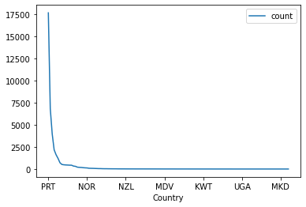

```python
h1['count'] = 1
c = h1.groupby('Country').agg({'count' : sum}).sort_values(by='count', ascending=False)
c.plot()
```

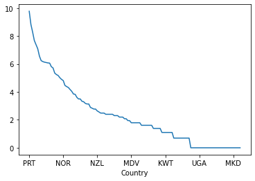

```python
# 로그스케일 변환 - 큰 값과 자근 값의 차이가 너무 큰 경우
# 작은 값 간의 크기 차이가 눈에 잘 보이지 않기 때문에 이 변환을 적용합니다.
c['count'].apply(lambda x : np.log(x)).plot()
```

### 예약자 국적별 예약 취소율 알아보기

- 국적으로 groupby -> agg IsCanceled 컬럼에 대해 평균
- 정렬해서 -> 어떤 나라가 가장 취소율이 높을까?

```python
country_group = h1.groupby('Country').agg({'IsCanceled' : np.mean})
sort_group = country_group.sort_values(by='IsCanceled', ascending=False)
sort_group
```

| Country | IsCanceled |
| --- | --- |
| SEN | 1.0 |
| JEY | 1.0 |
| TUN | 1.0 |
| SYC | 1.0 |
| GGY | 1.0 |
| ... | ... |
| JPN | 0.0 |
| JAM | 0.0 |
| ISL | 0.0 |
| IRN | 0.0 |
| ZWE | 0.0 |

125 rows × 1 columns

```python
valid = list(c.loc[c['count'] > 100].T.columns)
sort_group.T[valid].T.sort_values(by='IsCanceled', ascending=False)
```

| Country | IsCanceled |
| --- | --- |
| PRT | 0.421894 |
| RUS | 0.322751 |
| CHE | 0.257471 |
| SWE | 0.240132 |
| BRA | 0.234884 |
| ESP | 0.215062 |
| IRL | 0.199446 |
| NOR | 0.186992 |
| ROU | 0.180791 |
| ITA | 0.174292 |
| AUT | 0.161905 |
| USA | 0.150313 |
| CN | 0.135211 |
| BEL | 0.131696 |
| FRA | 0.130975 |
| GBR | 0.130760 |
| DEU | 0.121363 |
| POL | 0.117117 |
| NLD | 0.108949 |
| FIN | 0.105960 |
| CHN | 0.067164 |

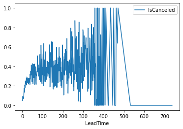

```python
h1.groupby('LeadTime').agg({'IsCanceled' : np.mean}).plot()
```

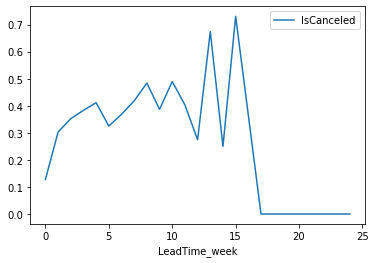

```python
h1['LeadTime_week'] = h1['LeadTime'].apply(lambda x : x // 30)
ga = h1.groupby('LeadTime_week').agg({'IsCanceled' : np.mean})
ga.plot()
```

##### 탐색으로 알 수 있었던 것

- 이 호텔은 전세계 125개국에서 방문합니다.
- 대부분의 고객은 내국인(PRT, 포르투갈인)입니다.
- 방문자 국적의 대부분은 몇 회 방문하지 않은 고객입니다.
- 예약을 가장 취소할 확률이 높은 고객군은 내국인입니다.
- 예약 신청날짜가 체크인날짜와 아주 가까운 경우,
- 가까울수록(급할수록) 예약 취소율 낮아짐

# 데이터 준비 단계

##### 문자열로 된 데이터(Categorical, Nominal)를 대하는 방법

### 기준 정했을 때 정도의 차이가 발생하는가?

- DepositType 컬럼은 예치금/환불규정입니다.
- 취소시 손님이 넘어야 할 심리적 장벽(?)을 기준으로 삼으면 크고 작음을 나타낼 수 있음.

```python
h1['DepositType'].unique()
```

```
array(['No Deposit     ', 'Refundable     ', 'Non Refund     '],
      dtype=object)
```

```python
sample = 'No Deposit     '
sample.strip()
```

```
'No Deposit'
```

```python
h1['DepositType'] = h1['DepositType'].apply(lambda x : x.strip())
h1['DepositType'].unique()
```

```
array(['No Deposit', 'Refundable', 'Non Refund'], dtype=object)
```

```python
mapper = {'No Deposit' : 0, 'Refundable' : 1, 'Non Refund' : 2}
h1['CustomerRisk'] = h1['DepositType'].map(mapper)
h1['CustomerRisk'].unique()
```

```
array([0, 1, 2], dtype=int64)
```

### 연습문제 - Meal 컬럼 변환

##### 예약시 식사를 같이 결제한 정보입니다.

- Undefined 또는 SC 인 경우 -> 식사 예약 X
- 식사 예약을 많이 할 수록 BB -> HB -> FB
- BB - Bed & Breakfast, HB - Half-Board, FB - Full-Board
- 따라서 Meal 컬럼은 호텔에 얼마나 길게 체류할 것인가를 나타냅니다.
- Meal 컬럼의 값을 0, 1, 2, 3 으로 정도를 나타내게 변환하여 Stay 컬럼을 만들어줍니다.

```python
h1['Meal'].unique()
```

```
array(['BB       ', 'FB       ', 'HB       ', 'SC       ', 'Undefined'],
      dtype=object)
```

```python
h1['Meal'] = h1['Meal'].apply(lambda x : x.strip())
h1['Meal'].unique()
```

```
array(['BB', 'FB', 'HB', 'SC', 'Undefined'], dtype=object)
```

```python
mapper = {'SC' : 0, 'Undefined' : 0, 'BB' : 1, 'HB' : 2, 'FB' : 3}
h1['Stay'] = h1['Meal'].map(mapper)
h1['Stay'].unique()
```

```
array([1, 3, 2, 0], dtype=int64)
```

##### tran / test set split

```python
h1.describe().columns
```

```
Index(['IsCanceled', 'LeadTime', 'ArrivalDateYear', 'ArrivalDateWeekNumber',
       'ArrivalDateDayOfMonth', 'StaysInWeekendNights', 'StaysInWeekNights',
       'Adults', 'Children', 'Babies', 'IsRepeatedGuest',
       'PreviousCancellations', 'PreviousBookingsNotCanceled',
       'BookingChanges', 'DaysInWaitingList', 'ADR',
       'RequiredCarParkingSpaces', 'TotalOfSpecialRequests', 'count',
       'LeadTime_week', 'CustomerRisk', 'Stay'],
      dtype='object')
```

```python
label = 'IsCanceled'
# IsCanceled 컬럼은 맞추고자 하는 label에 해당하므로 따로 빼서 label 변수에 넣습니다.
features = ['LeadTime', 'ArrivalDateYear', 'ArrivalDateWeekNumber',
       'ArrivalDateDayOfMonth', 'StaysInWeekendNights', 'StaysInWeekNights',
       'Adults', 'Children', 'Babies', 'IsRepeatedGuest',
       'PreviousCancellations', 'PreviousBookingsNotCanceled',
       'BookingChanges', 'DaysInWaitingList', 'ADR',
       'RequiredCarParkingSpaces', 'TotalOfSpecialRequests', 'count',
        'CustomerRisk', 'Stay']
```

```python
train, test = h1[0::2].reset_index(), h1[1::2].reset_index()
X_train, y_train = train[features], train[label]
X_test, y_test = test[features], test[label]
# 여기까지가 데이터 준비 단계 마지막입니다.
```

# 모델 기획 / 수립

```python
from sklearn.tree import DecisionTreeClassifier as dt
from sklearn.tree import export_graphviz as eg
model = dt(max_depth = 5)
model.fit(X_train, y_train)
eg(model, out_file='tree_05.txt',
   feature_names=features, class_names=['no', 'yes'])
```

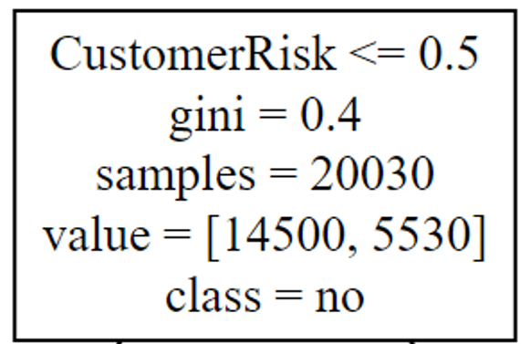

```python
'''
CustomerRisk - 0 = 예치금 x, 1 = 전화하면 환불가능
LeadTime - 2주 이상 전에 예약
RequiredCarParkingSpaces  - 차 가지고 가요.
위 3개 조건을 동시에 만족하는 경우 전부 예약 취소 안했음
'''
split_1 = train.loc[train['CustomerRisk'] <= 1.5]
split_2 = split_1.loc[split_1['LeadTime'] > 13.5]
split_3 = split_2.loc[split_2['RequiredCarParkingSpaces'] > 0.5]
split_3['IsCanceled'].sum()
```

```
0
```

# 알고리즘에서 나오는 용어 정리

##### ensemble(앙상블), bagging(배깅), boosting(부스팅)

##### ensemble

- 최종 결과를 내기 위해서 작은 알고리즘들을 여러 개 이용하는 경우
- 숫자를 예측하는 경우에는 알고리즘들의 결과값을 평균
- 경우의 수를 예측하는 경우에는 알고리즘들의 결과를 투표

##### bagging = bootstrap + aggregation

- bootstrap? -> 데이터의 row를 추출해서 새로운 데이터 셋 만들기(복원추출)
- 복원추출? -> 뽑았는데 안 뽑았다고 치고 원본에 남겨 놓는 것(다음 번에도 뽑힐수있게)
- sklearn.ensemble import RandomForestRegressor -> random forest 알고리즘
- bagging 을 이용하는 가장 대표적인 알고리즘.
- 서로 조금씩 다른 데이터 셋을 bootstrap 방식으로 만들어내고
- 각 데이터 셋에 대해 의사결정나무 알고리즘으로 따로따로 학습
- 그렇게 만들어진 여러 개의 의사결정나무 알고리즘 결과를 합산(aggregate)하여 결과냄.

##### boosting

- 오답노트와 유사한 접근법.
- 학습 후 예측하면 잘 맞추는 문제(row)와 못 맞추는 문제를 알 수 있습니다.
- 못 맞추는 문제(row)를 어떻게든 더 잘 맞출 수 있게하는 접근방식
- 예_1) 하나 학습해서 예측한 다음 못 맞추는 row를 더 샘플링으로 뽑아서
- 새로운 데이터 셋 만들고 새로운 알고리즘 만들어서 학습
- 예_2) 한 알고리즘이 예측할 때 맞춘 row와 못 맞춘 row가 있을텐데
- 못 맞춘 정도를 새로운 label로 삼아서 동일한 데이터에 대해 label만 바꿔서
- 새로운 알고리즘으로 학습
- 통계적 머신러닝 계열에서 최고의 성능을 자랑(딥러닝 포함해서 성능이 좋은 경우 많다.)
- XGBoost, lightgbm 이 대표적인 예시
- 잘 못 쓰면 overfit(과적합, train good / test bad) 무조건 발생.

```python
from sklearn.ensemble import RandomForestClassifier as rf
model = rf()
model.fit(X_train, y_train)
```

```
RandomForestClassifier()
```

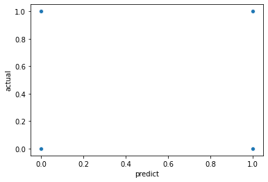

```python
import seaborn as sns
for_plot = pd.DataFrame()
for_plot['predict'] = model.predict(X_test)
for_plot['actual'] = y_test
sns.scatterplot(data=for_plot, x='predict', y='actual')
# 자전거 대여량 데이터와 마찬가지로 실제 값과 예측 값을
# 산점도 그래프로 나타내었습니다.
# 점이 4개밖에 안 보이는데, 이 이유는
# label 이 0 또는 1이고 예측모델 예측 결과도 0 또는 1이기 때문입니다.
```

##### 분류 문제의 평가지표

- confusion matrix(혼동행렬)

```python
from sklearn.metrics import confusion_matrix as cm
cm_data = cm(for_plot['actual'], for_plot['predict'])
TN, FP, FN, TP = cm_data.ravel()
print(TN, FP, FN, TP)
```

```
13630 808 2236 3356
```

- TF -> 맞춘 것이 True, 틀린 것이 False
- PN -> 예측 결과가 1 이 Positive, 예측 결과가 0 이 Negative
- 위 4개는 TF 에서 하나, PN에서 하나 뽑아서 만든 이름입니다.

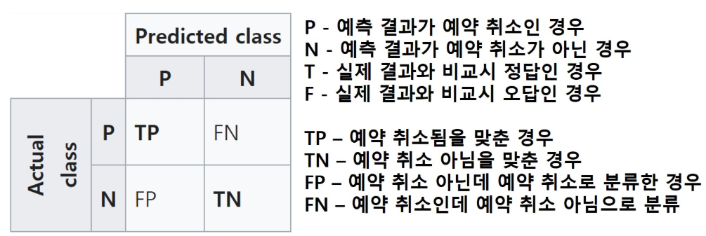

##### 화재경보장치 - 1이 알람 울림, 0이 알람 안울림

- FP = False Positive -> False Alarm
- FN = False Negative -> Miss

##### 환자 검진에 사용시 - 1이 양성(걸렸다고 판단), 0이 음성(안걸렸다고 판단)

- FP = False Positive -> 검사에서는 병 걸렸다고 했는데 사실 정상
- FN = False Negative -> 검사에서는 병에 안 걸렸다고 했는데 사실 걸림.ㅠ

##### 금융 사기 탐지에 사용시 - 1이 사기라고 판단, 0이 사기 아니라고 판단

- FP = False Positive -> 사기인줄 알았으나 사기가 아니었음
- FN = False Negative -> 사기 아닌줄 알았는데 사실은 사기당한거였음

##### 스팸 메일 분류에 사용시 - 1이 스팸이라 판단, 0이 스팸 아니라고 판단

- FP = False Positive -> 스팸이라 판단했으나 아니었음
- FN = False Negative -> 스팸이 아니라 판단했으나 스팸이었음

##### 어뷰징 유저 판단에 사용시 - 1이 어뷰징이라 판단, 0이 어뷰징 아니라고 판단

- FP = False Positive -> 어뷰징이라 판단했으나 아니었음
- FN = False Negative -> 어뷰징이 아니라 판단했으나 어뷰징이었음

##### Trade-off 관계

- 하나를 얻으면 하나를 잃는 상황
- 모든 것을 얻을 수 없다는 의미
- 예) 노트북 화면 크고 성능 좋은데 가벼웠으면 좋겠음, 그리고 100만원 이하!

# accuracy, precision, recall, fall-out

- accuracy -> 전체 중에서 맞춘 비율
- precision -> 예측 모델이 1(Positive)로 예측한 것 중 맞춘 것 비율 TP / (TP + FP)
- recall -> 실제값이 1 인 것 중 맞춘 것 비율 TP / (TP + FN)
- fall-out -> 실제값이 0 인 것 중 틀린 것 비율 FP / (FP + TN)

```python
acc = (TP + TN) / (TP + TN + FP + FN)
acc # 전체 개수 중 맞춘 비율
```

```
0.8480279580629057
```

```python
prec = TP / (TP + FP) # F - 틀림, P - 1 이라고 예측
prec # 알고리즘이 1 이라고 했으면 얼마나 믿을 수 있나?
```

```
0.8059558117195005
```

```python
recall = TP / (TP + FN)
recall # 실제 1 인 것들 중에 얼마나 맞췄나?
```

```
0.600143061516452
```

```python
all_len = len(train)
actual_1_count = train['IsCanceled'].sum()
actual_0_count = all_len - actual_1_count
print(actual_1_count, actual_0_count)
```

```
5530 14500
```

```python
# 걸림 = 100, 안걸림 = 1000000
```

```python
tp = 0
tn = 1000000
fp = 0
fn = 100
acc = (tp + tn) / (tp + tn + fp + fn)
acc # 전체 개수 중 맞춘 비율
```

```
0.9999000099990001
```

```python
acc = (TP + TN) / (TP + TN + FP + FN)
prec = TP / (TP + FP)
recall = TP / (TP + FN)
fall_out = FP / (FP + TN)
```

##### ROC Curve, PR Curve

- 분류 문제에서는 ROC Curve 라는 것을 그려서 성능이 얼마나 좋은지 판단합니다.
- 3개의 서로 다른 알고리즘들을 이용하여 각각 ROC Curve를 그리고
- 어떻게 해석할지를 다룹니다.

```python
from sklearn.tree import DecisionTreeClassifier as dt
from sklearn.ensemble import RandomForestClassifier as rf
from sklearn.ensemble import GradientBoostingClassifier as gb
m1, m2, m3 = dt(), rf(), gb()
m1.fit(X_train, y_train)
m2.fit(X_train, y_train)
m3.fit(X_train, y_train)
```

```
GradientBoostingClassifier()
```

```python
r1 = pd.DataFrame(m1.predict_proba(X_test), columns=['neg', 'pos'])
r2 = pd.DataFrame(m2.predict_proba(X_test), columns=['neg', 'pos'])
r3 = pd.DataFrame(m3.predict_proba(X_test), columns=['neg', 'pos'])
```

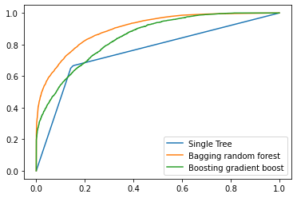

```python
from sklearn.metrics import roc_curve
import matplotlib.pyplot as plt
x1, y1, _ = roc_curve(y_test, r1['pos'])
x2, y2, _ = roc_curve(y_test, r2['pos'])
x3, y3, _ = roc_curve(y_test, r3['pos'])
plt.plot(x1, y1, label='Single Tree')
plt.plot(x2, y2, label='Bagging random forest')
plt.plot(x3, y3, label='Boosting gradient boost')
plt.legend()
```